# A3: Data set Pathway and Network Analysis

Kobi Schmalenberg

# Packages Used

GEOquery, biomaRt, clusterProfiler, org.Hs.eg.db Huber W (2015), kableExtra H (2024), dplyr Wickham H (2023), DESeq2 Love MI (2014), edgeR Yunshun Chen (2010), limma Richie ME (2015), ComplexHeatmap Gu Z (2016), circlize Z (2014), GSEA Mootha K (2003), ggplot2 Wickham (2016), RCy3 Shannon P (2003)

# Data Source Refresher/Introduction

**Data Source:** GSE208438 Kaiqin Lu (2023). Data was downloaded using the GEOquery package.

**Dataset Information:** The dataset used for this assignment is the entire bulk-seq library consisting of 3 post-mortem suicidal Major Depressive Disorder patient samples as well as 3 control samples. RNA sequencing was completed using Illumina HiSeq<sup>TM</sup> 2500 and reads were aligned to the GRCh38 human reference genome and transcriptome.

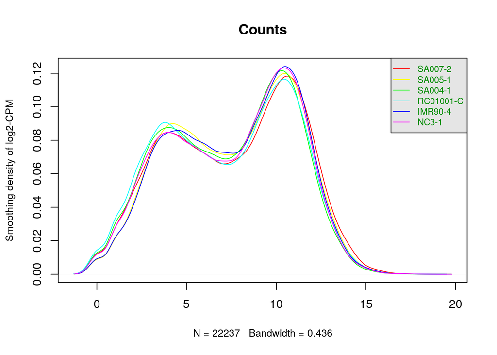

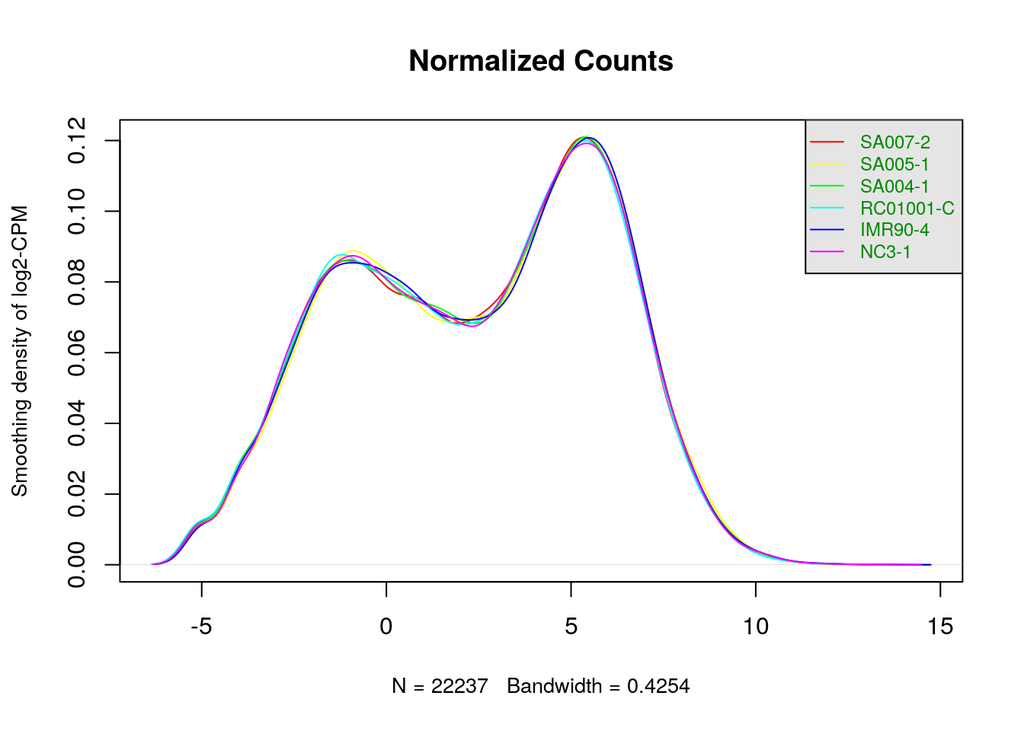

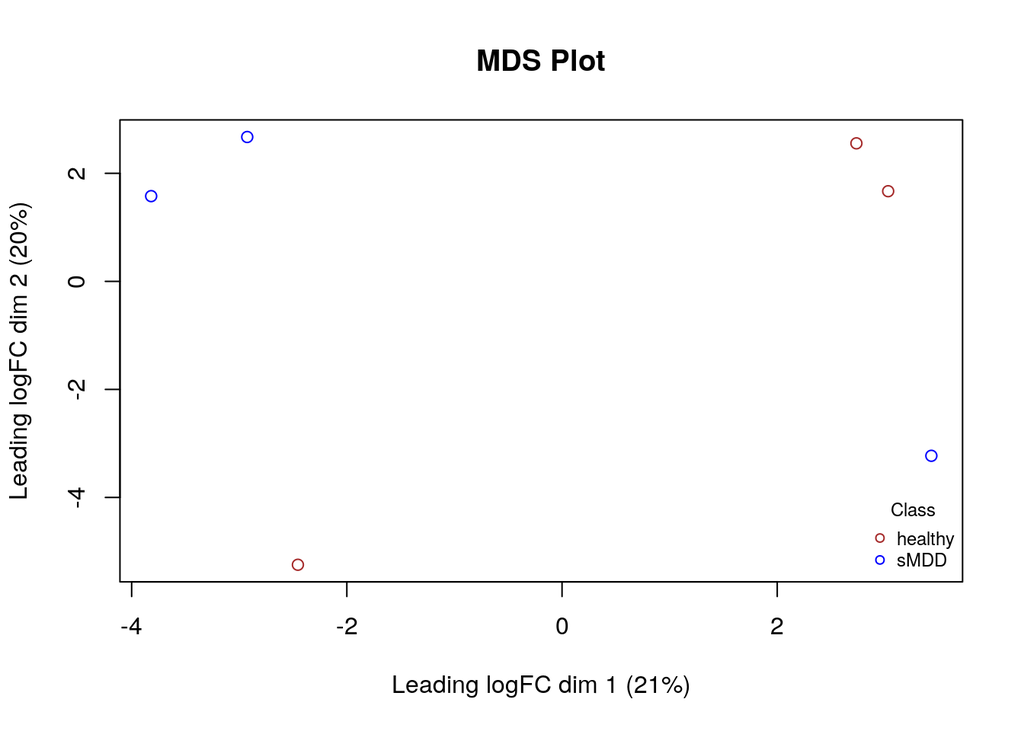

How many genes were significantly differentially expressed? -> 1285.

How many genes passed correction? -> 0.

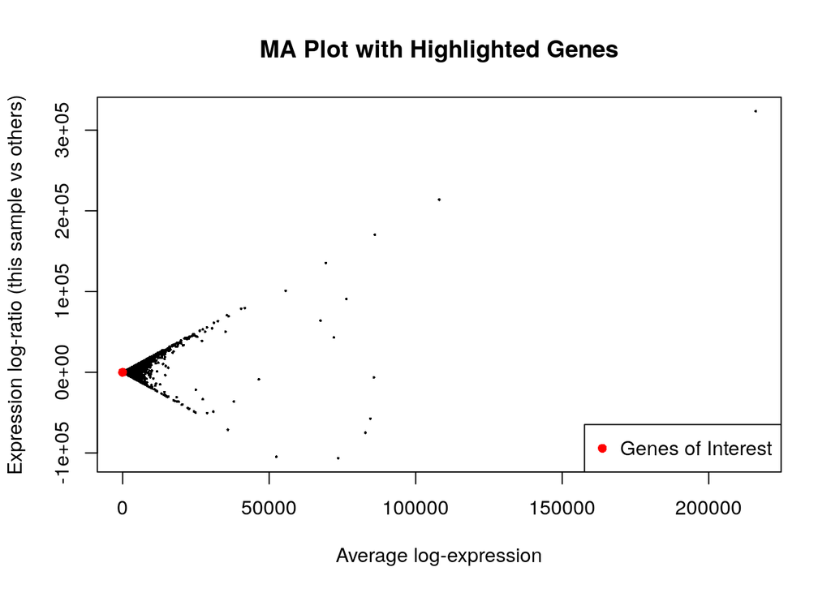

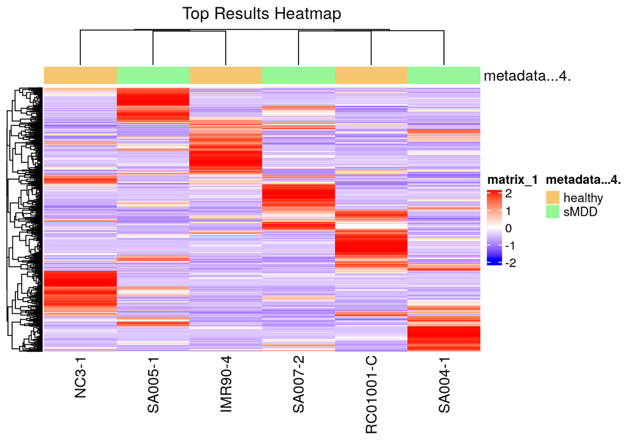

The above heatmap shows up and down regulated regions in both healthy and sMDD samples.

How many genesets were returned with what thresholds?

# Non-threshold Gene set Enrichment Analysis

```r
# # This is the code used to perform GSEA analysis, for the purposes of time efficiency, all of it will be commented out.
#
# # Creating a rank file
#
# # Sort genes by p-value
# sorted_genes <- glm_output$table[order(glm_output$table$PValue), ]
#
# # Assign ranks based on sorted order
# sorted_genes$rank <- 1:nrow(sorted_genes)
#
# # Add gene ID as a column from rownames
# sorted_genes$GeneName <- rownames(sorted_genes)
#
# # Write rank file to a text file
# write.table(sorted_genes[, c("GeneName", "rank")], file = "rank_file.rnk", sep = "\t", row.names = FALSE, quote = FALSE)
#
# rnk_file <- "rank_file.rnk"
#
# gsea_jar <- "GSEA_4.3.3/GSEA_4.3.3/gsea-cli.sh"
#
# working_dir <- "./"
#
# output_dir <- "./output" # input the name a folder you would like to output results to
#
# analysis_name <- "Non-thresholded GSEA"
#
# # URL to the ranked gene list file
#
# gmt_url = "https://download.baderlab.org/EM_Genesets/current_release/Human/symbol/"
#
# # List all the files on the server
# filenames = getURL(gmt_url)
# tc = textConnection(filenames)
# contents = readLines(tc)
# close(tc)
#
# dest_gmt_file <- file.path(output_dir,"Human_GOBP_AllPathways_noPFOCR_with_GO_iea_March_01_2024_symbol.gmt.txt")
#
# gmt_data <- readLines(dest_gmt_file)
#
# # Convert gene set names to lowercase
# gene_sets <- lapply(strsplit(gmt_data, "\t"), function(x) {
#   x[1] <- tolower(x[1])
#   return(x)
# })
#
# # Remove duplicate gene set names (keeping the first occurrence)
# unique_gene_sets <- unique(gene_sets)
#
# run_gsea <- TRUE
#
# # Load gene sets data
# if(run_gsea){
#   command <- paste("",gsea_jar,
#                    "GSEAPreRanked -gmx", dest_gmt_file,
#                    "-rnk" ,file.path(working_dir,rnk_file),
#                    "-collapse false -nperm 1000 -scoring_scheme weighted",
#                    "-rpt_label ",analysis_name,
#                    "  -plot_top_x 20 -rnd_seed 12345  -set_max 200",
#                    " -set_min 15 -zip_report false ",
#                    " -out" ,output_dir,
#                    " > gsea_output.txt",sep=" ")
#   system(command)
# }
```

1. What method did you use? What genesets did you use?

I used GSEA version 4.3.3 Mootha K (2003) to perform enrichment analysis as I already have access to the necessary files for the analysis and had p-value data prior that could be used to make rankings of my genesets. I used the genesets from Assignment 2 that have had differential expression and threshold over-representation analysis performed on them. The genesets originally come from GSE208438 Kaiqin Lu (2023) and include the entire bulk-seq library consisting of 3 post-mortem suicidal Major Depressive Disorder patient samples as well as 3 control samples.

2. Summarize your enrichment results.

**na_pos Results**

- 6323 out of 6380 gene sets are upregulated in phenotype na_pos
- 2 gene sets are significant at FDR < 25%
- 50 gene sets are significantly enriched at nominal p-value < 1%
- 260 gene sets are significantly enriched at nominal p-value < 5%

**na_neg Results**

# Visualize your Gene set Enrichment Analysis in Cytoscape

1. Create an enrichment map - how many nodes and how many edges in the resulting map? What thresholds were used to create this map? Make sure to record all thresholds. Include a screenshot of your network prior to manual layout.

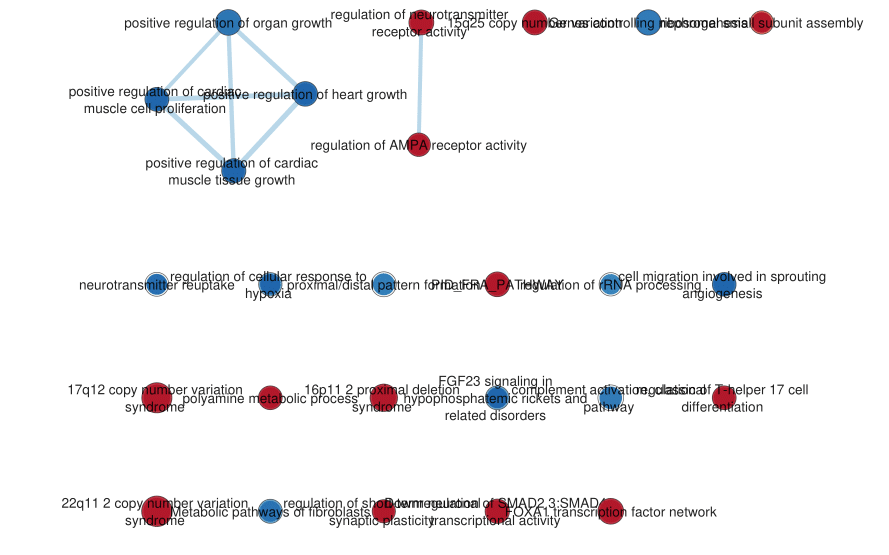

**Figure 1**: Default cytoscape network construction using EnrichmentMap with GSEA output.

There are a total of 26 nodes and 7 edges. 6 edges form a cluster while the last edge forms a connection between two nodes. FDR cutoff of 0.9 was used as results for values from 0.01 to 0.8 displayed fewer than 5 nodes.

2. Annotate your network - what parameters did you use to annotate the network. If you are using the default parameters make sure to list them as well.

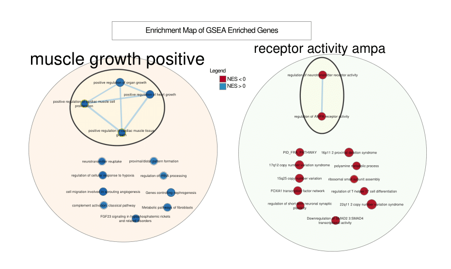

**Figure 2**: Cytoscape network construction after using AutoAnnotate. Orange and green circles are manually added to group NES pos and neg nodes.

AutoAnnotate was run using the default parameters. Defaults are as follows:

- Use clusterMaker app
  - Cluster algorithm: MCL Cluster
  - Edge weight column: None
- Label Column: GS_DESCR
- Label Algorithm: WordCloud: Adjacent Words
- Max words per label: 3
- Minimum word occurence: 1
- Adjacent word bonus: 8
3. Make a publication ready figure - include this figure with proper legends in your notebook.

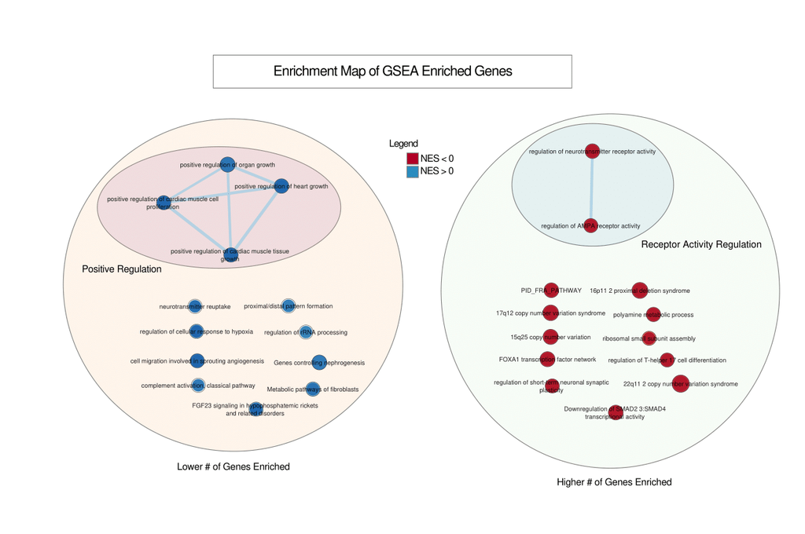

GSEA Theme-annotated Cytoscape Network

**Figure 3**: Cytoscape network construction after manual annotations and grouping by connected nodes or similar nodes.

Legend in the figure applies meaning to the node colouring. Red corresponding to NES negative values, with darker red being more negative. Blue corresponding to NES positive values, with darker blue being more positive.

4. Collapse your network to a theme network. What are the major themes present in this analysis? Do they fit with the model? Are there any novel pathways or themes?

# Interpretation

1. Do the enrichment results support conclusions or mechanism discussed in the original paper? How do these results differ from the results you got from A2 thresholded methods.

The results from GSEA and cytoscape network enrichment do not directly match with the results from A2. In A2 we found a number of matching and differing up and downregulated genes with reference to the original paper whereas we do not see the same genes in the results of this assignment.

2. Can you find evidence, i.e. publications, to support some of the results that you see. How does this evidence support your result?

Yes, from a study by Ting Fan, et al. Fan T (2020) it is found that regulation of synaptic plasticy is enriched in MDD genes. This term is also enriched in our analyses. The only caviat here is that we are looking at specifically sMDD genes wheras the study focusses on MDD genes in general. Looking at the results from sMDD and MDD genes in comparison may lead discussions on the enriched GO terms that are only present in sMDD genes. This may help guide researchers in discovering patterns in suicidal patients among MDD patients.

3. Choose a specific pathway or theme to investigate in more detail. Why did you choose this pathway or theme? Show the pathway or theme as a gene network or as a pathway diagram. Annotate the network or pathway with your original log fold expression values and p-values to show how it is effected in your model.

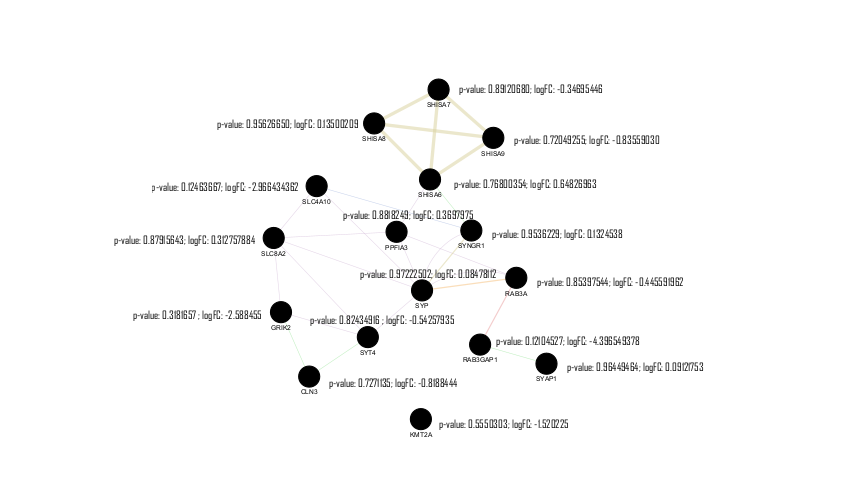

**Figure 4**: GeneMania network analysis of the regulation of short-neuronal synaptic plasticity pathway(node).

# References

Fan T, Xin J, Hu Y. 2020. “Analyzing the Genes and Pathways Related to Major Depressive Disorder via a Systems Biology Approach.” *Brain Behav.* https://doi.org/10.1002%2Fbrb3.1502.

Gu Z, Schlesner M, Eils R. 2016. “Complex Heatmaps Reveal Patterns and Correlations in Multidimensional Genomic Data.” *Bioninformatics*. https://doi.org/10.1093/bioinformatics/btw313.

H, Zhu. 2024. “kableExtra: Construct Complex Table with ’Kable’ and Pipe Syntax.” *R Package Version 1.4.0*. https://CRAN.R-project.org/package=kableExtra.

Huber W, Gentleman R, Carey V. 2015. “Orchestrating High-Throughput Genomic Analysis with Bioconductor.” *Nat Methods*. https://doi.org/10.1038/nmeth.3252.

Kaiqin Lu, Mengdan Tao, Yuan Hong. 2023. “Depressive patient-derived GABA interneurons reveal abnormal neural activity associated with HTR2C.” *EMBO Mol Med.* 15. https://doi.org/10.15252/emmm.202216364.

Love MI, Anders S, Huber W. 2014. “Moderated Estimation of Fold Change and Dispersion for RNA-Seq Data with DESeq2.” *Genome Biology*. https://bioconductor.org/packages/release/bioc/html/DESeq2.html.

Mootha K, Eriksson F, Lindgren M. 2003. “PGC-1alpha-Responsive Genes Involved in Oxidative Phosphorylation Are Coordinately Downregulated in Human Diabetes.” *Nat Genet*. https://doi.org/10.1038/ng1180.

Richie ME, Wu D, Phipson B. 2015. “Limma Powers Differential Expression Analyses for RNA-Sequencing and Microarray Studies.” *Nucleic Acids Research*. doi:10.1093/nar/gkv007.

Shannon P, Ozier O, Markiel A. 2003. “Cytoscape: A Software Environment for Integrated Models of Biomolecular Interaction Networks.” *Genome Res*. https://doi.org/10.1101/gr.1239303.

Wickham H, Henry L, François R. 2023. “dplyr: A Grammar of Data Manipulation.” *R Package Version 1.1.4*. https://CRAN.R-project.org/package=dplyr.

Wickham, Hadley. 2016. “Ggplot2: Elegant Graphics for Data Analysis.” https://ggplot2.tidyverse.org.

Yunshun Chen, Davis M, Aaron L. 2010. “edgeR: A Bioconductor Package for Differential Expression Analysis of Digital Gene Expression Data.” *Bioinformatics*. doi:10.1093/bioinformatics/btp616.

Z, Gu. 2014. “Circlize Implements and Enhances Circular Visualization in r.” *Bioninformatics*. https://doi.org/10.1093/bioinformatics/btu393.